# Seminar 5:

## AD-AS modellen under flytende kurs

Vi tenker oss at økonomien som vi seer er i samtidig likevekt og at målene om intern og ekstern balanse er oppfylt.

1. Illustrer i et AD-AS diagram effekten av en renteøkning i utlandet (eks. situasjonen USA vs. Norge) på kort og mellomlang sikt
2. Under AD-AS modellen for fast-kurs, har det blitt vist i forelesningen at etter en oppgangkonjunktur kan bli ledsaget av en nedgangskonjunkturfor å nå de to målene om intern og ekstern balanse. Forklar hvilken mekanisme som kan forhindre en slik utvikling under flytende kurs *Valutakursforventningen endres*
3. Hvordan bør pengepolitkken endres dersom den skal nøytralisere effekten av den utenlandske renteøkningen? *Pengemengen bør øke slik at renta går ned, men ikke like mye som i utlandet. Illustreres best ved IS-LM diagram*

## Solow-modellen for økonomisk vekst

1. Løs modellen normal utgave for kapitaldynamikkligningen

*$$\frac{\dot{K}}{K} = I -\delta = \frac{sY}{K} -\delta = \frac{sY/N}{K/N} -\delta= \frac{sy}{k} -\delta$$*

$$\frac{\dot{k}}{k} + n + a= -\delta + \frac{sy}{k} \Leftrightarrow \\
\dot{k} = sf(k)-(\delta+n+ a) k$$

2. Vis i en figur hva som skjer i økonomien dersom fødselsraten går ned?

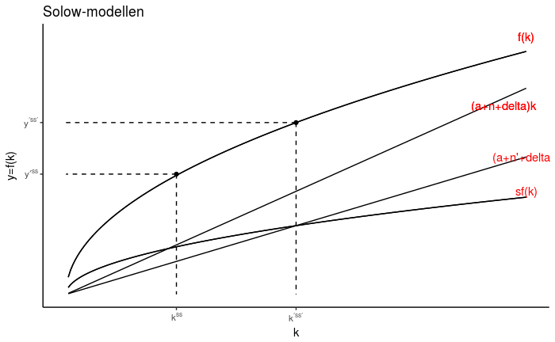

*Går mot ny stasjonærtilstand med høyere BNP per effektiv arbeider*

3. Hvilken forutsetning gjør modellen uegnet til å studere pensjonspolitikk

*Hele befolkningen i økonomien er i arbeid, $N=L$*

4. Solow-modellen er uten noen forklaring på hva som skaper teknologisk framgang (parameteren a er bestemt utenfor modellen). Hva mener du kan gjøres for å øke veksten i denne parameteren?

*FoU, utdanning, mer effektive lover og regler, IKT, forbedret offentlig institusjoner*